# Using Network Measures of Functional Brain Activity to Predict Personality

Jared P. Zimmerman, Jennifer Stiso, Katerina Placek

11/14/2017

# Executive Overview

# Data Description

```r
#loading in data
dataFiles <- c('allData_ic149_fullCor_n810_noG.csv', 'allData_ic149_pCor_n810_noG.csv')
corNames <- c('full', 'partial')
data <- lapply(dataFiles, read.csv, stringsAsFactors = TRUE)
names(data) <- corNames
```

[output not shown]

## Human Connectome Project

The Human Connectome Project (HCP) is a multi-center consortium funded by the NIH with the goal of mapping the macroscale structural and functional connectivity of the human brain (Van Essen et al. 2013). In total, the project collected neuroimaging data including structural magnetic resonance imaging (MRI), resting-state functional MRI, task-based functional MRI, and diffusion spectrum imaging, as well as subject measures including behavioral and cognitive assays, demographic data, and health data on over 1200 healthy young adults. These data have all been publically released in raw, processed, and highly-processed formats as resources for the research community. For this project, we utilize some of the highly-processed data from the Parcellations, Timeseries, and Netmats (PTN) release. Specifically, we use the netmats, or network matrices, data. For the PTN release, the HCP consortium used group independent component analysis (ICA) on processed rs-fMRI data to create a data-driven parcellation of the brain by identifying independent sources of variation within and across subjects. Following group ICA, a dual regression approach is used to fit the group-average parcellation template to each individual subject (Smith et al. 2013, Smith et al. 2014). This dual-regression step results in subject-specific maps and a corresponding timeseries for each ICA component. After dual-regression ICA, functional network connectivity matrices were constructed for each subject as $N*N$ matrices where $N$ is the number of ICA components and each matrix element $E_{ij}$ represents the functional connectivity between nodes $i$ and $j$. The ‘functional connectivity’ between two network nodes (i.e. ICA components) is operationalized as some measure of the similarity in the timeseries of the two brain regions. A variety of measures have been proposed as measures of functional connectivity, however by far the most common measure is a simple Pearson’s correlation of the timeseries. There is some debate, however, about whether Pearson’s correlation is a good measure that actually represents “true” connections between brain areas, and it has been proposed that a more accurate measure of direct connections might be to use the partial correlation between regions (Smith et al. 2011). With partial correlation, the time-series of all other network nodes is regressed out of nodes $i$ and $j$ before estimating their correlation to give a more accurate measure of the information uniquely shared between the two regions. Because there is no obvious ground truth for functional brain networks, it is difficult to determine which measure gives a more accurate representation of the connectivity structure of the brain. Prediction offers one possible solution to this problem. Under the hypothesis that perception, affect, cognition, and behavior result from brain activity, the brain network method that is best able to predict these might be the most accurate representation of the connectivity structure of the brain. For this reason, we have chosen to compare the predictive power of brain network constructed with both full and partial correlations.

Additionally from the HCP we have structural brain data. These measures were derived by running the FreeSurfer structural analysis pipeline on the T1 structural MRI scans of HCP subjects. FreeSurfer performs automated brain segmentation and cortical surface parellation producing accurate and reproducible measurements of brain structure (Fischl, 2012).

## The NEO Five Factor Inventory

The NEO Five Factor Inventory (NEO-FFI) is a short, 60-item personality inventory designed to measure a person’s ‘Big Five’ personality traits: openness to experience, conscientiousness, extraversion, agreeableness, and neuroticism (Costa & McCrae, 1992). The ‘Big Five’ personality traits derive from the eponymous Five Factor Model, which suggests that a person’s personality can be described along the aforementioned five dimensions. The name ‘NEO’ is a historic reflection of the test’s original goal of measuring personality characteristics of neuroticism, extraversion, and openness to experience, with agreeabless and conscientiousness more recent additions not reflected in the test name. The NEO-FFI is completed in a self-report format, and contains 12 items designed to assess each of the five factors. Each item consists of a statement about the participant, for example “I donât get much pleasure chatting with people.” Participants are required to rate their agreement with each given statement as ‘Strongly Disagree’, ‘Disagree,’ ‘Neutral’, ‘Agree’, or ‘Strongly Agree.’ Scores are derived for each of the Five Factors based on the participants answers. Briefly, points are allotted to each item based on the participant’s answer, and a Five Factor score is generated by summing the points for the 12 items associated with a factor and assigning a T value based on test norms. The NEO-FFI has been widely validated for use in the assessment of personality in healthy populations and for the assessment of clinically-defined personality disorders according to the Diagnostic and Statistical Manual of Mental Disorders - Version 5 (Trull, 2012). In addition to other various self-report measures, The NEO-FFI was collected on HCP participants and we include both the raw data (i.e. score on each of 60 items) and the Five Factor data (i.e. score for each of the five factors) in our dataset.

## Network Measures

Recently, the field of neuroscience has begun to incorporate mathematical formalisms from graph theory to try and succintly quantify how regions of the brain interact as a cohesive network. In this approach, brain regions are defined as nodes, connected by edges (Fig 1A). The presence of an edge (usually a statistical interdependency, such as correlation of activity) is interpreted as an indication that two regions have similar activity, and are said to be functionally connected. We have chosen several graph statistics common to neuroscience to include in our analysis, with the hypothesis that they might better capture meaningful features of the brain than individual connections alone. While others have explored the relationship between edges, and personality measures, it is unclear how these more comprehensive summary statistics will explain variances in NEO-FFI scores.

These measures can be divided into two categories: (1) node statistics, which describe properties of a single node, and it’s connections to other nodes, and (2) network statistics, which describe the structure of all connections in a graph. We will first discuss network statistics. The first network statistic calculated is the $\textit{global efficiency}$ (Fig B2). This measure is proportional to the average distance between a single node, to any other nodes by travelling along edges. The next measure is a $\textit{community partition}$ (Fig B3). This breaks a nextwork into communities, where the nodes in a community will have more connections within that community, than between between communities. We will now discuss node statistics. The first, and most intuitive measure is $\textit{strength}$ (Fig B1). The strength is simply the sum of all edges connected to a given node. The second measure is $\textit{betweenness centrality}$. Betweenness centrality is the fraction of all shortest paths in a network that pass through a given node. Intuitively, nodes with high betweenness centrality are thought to be important for communication between many, distant groups. The last measure is $\textit{within module degree}$, which quantifies the proportion of a nodes connections that are within a community.

Firgure 1: Schematic of Network Measures

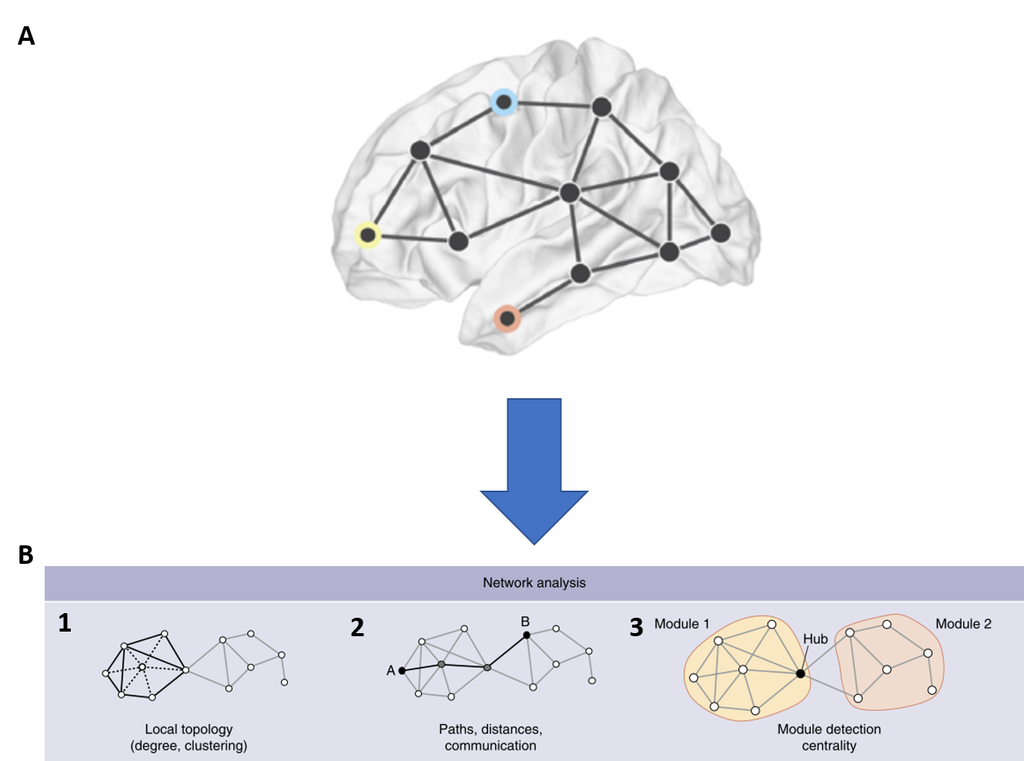

```r
knitr::include_graphics("/Users/jenis/Documents/R/Final/full_network_ex.png")
```

```r
#Bassett & Sporns 2017
```

# Data Cleaning

## Variable Selection

First, we exclude some variables and modify some variables included in the HCP data release that are not of interest for the current project. In particular, the FreeSurfer brain anatomy data includes a number of measures of no interest. Some examples include `FS_BrainSeg_Vol` which is a measure of total volume of the brian segmentation. This is redundant with the measure `FS_IntraCranial_Vol` which is a measure of total intracranial volume and is more commonly used as a measure of general head size. Additionally, other measures we exclude here are general measures of the entire brain or measures of brain tissue classes instead of specific brain regions, such as `FS_Tot_WM_Vol` which is the measure of total white-matter volume. Also some of the FreeSurfer measures are not measurements of the brain, but rather measurements of the quality of the brain segmentation algorithms, such as `FS_Total_Defect_Holes`.

We exclude these variables and others from our dataset:

```r
data2 <- lapply(data, function(x) {

  x %>%
    dplyr::select(-X, -Subject, -FS_BrainSeg_Vol, -FS_BrainSeg_Vol_No_Vent, -FS_BrainSeg_Vol_No_Vent_Surf,
                  -FS_LCort_GM_Vol, -FS_RCort_GM_Vol, -FS_TotCort_GM_Vol, -FS_SubCort_GM_Vol, -FS_Total_GM_Vol, -FS_SupraTentorial_Vol, -FS_R_WM_Vol, -FS_Tot_WM_Vol, -FS_Mask_Vol,  -FS_BrainSegVol_eTIV_Ratio, -FS_MaskVol_eTIV_Ratio, -FS_LH_Defect_Holes,  -FS_RH_Defect_Holes, -FS_Total_Defect_Holes, -FS_L_WM_Hypointens_Vol, -FS_R_WM_Hypointens_Vol, -FS_WM_Hypointens_Vol)
})
```

## Scaling

Of the brain structural measures we retain, there are two types of measures. For subcortical brain regions we have measures of regional volume, and for cortical brain regions we have measures of cortical thickness. Thickness is used for cortical structure because the cortex is represented as a set of two two-dimensional surfaces, and the thickness is calculated as the Euclidean distance between corresponding vertices of these two surfaces.

To control for the effect of head size and brain size all of the subcortical volumes, we scale by the total intracranial volume estimated by FreeSurfer.

```r
fs_scaled <- as.data.frame(sapply(data2$full[ , grep("FS_.*_Vol", names(data2$full))], function(x) {
  x/data2$full$FS_IntraCranial_Vol
}))
fs_scaled <- fs_scaled[,-1]
names(fs_scaled) <- paste0(names(fs_scaled), "_scaled")
```

The scaled volumes are retained, and all unscaled volumes excluding total intracranial volume are dropped.

```r
data3 <- lapply(data2, function(x) {
  cbind(x, fs_scaled)
})
data3 <- lapply(data3, function(x) {
  x[,-grep("FS_.*_Vol$", names(x))[-1]]
})
```

## Separation of NEO data and HCP data into distinct dataframes

Next, for use in our analyses, we separate the HCP data from the NEO-FFI data.

First, we save out the Five Factor score data and raw NEO-FFI data each to a separate dataframe.

```r
neoFFData <- data3$full[, grep("NEOFAC.*", names(data3$full))]
neoRData <- data3$full[, grep("NEORAW.*", names(data3$full))]
```

Last, we remove all raw NEO data and Five Factor Score data from the original matrix, retaining only HCP measures.

```r
data4 <- lapply(data3, function(x) {
  x[,-grep("NEO*", names(x))]
})
lapply(data4, dim)
```

```
$full
[1]   810 11734

$partial
[1]   810 11734
```

Our final cleaned HCP dataset has 810 observations and 11734 features.

## Split into Training and Test Samples

We split the dataset into training and testing samples. We choose to make this split to separate the testing data from data used to fit parameters, despite the fact that random forest’s out of bag predictions can be used for an out of sample prediction The training dataset includes 710 observations and the testing set includes 100. We chose a rather high training fraction because we have a wide dataset and would like to retain as many observations as possible for training. One hundred observations should be sufficient to estimate the out-of-sample testing error.

```r
set.seed(1)
idx = sample(1:810, size=100)
data.train <- lapply(data4, function(x){
  x[-idx,]
})
data.test <- lapply(data4, function(x){
  x[idx,]
})
neoFFData.train <- neoFFData[-idx,]
neoFFData.test <- neoFFData[idx,]
```